### Студент: Калугина Дарья

### Группа: РИ-450004

# Домашнее задание № 2

## Основы исследовательского анализа данных.

## Исходные данные

По адресу https://raw.githubusercontent.com/SergeyMirvoda/da2016/master/data/calif_penn_2011.csv можно получить набор данных, содержащий информацию о домовладениях в Калифорнии и Пенсильвании за 2011г. Информация сгруппированна по зонам переписи ([Census tracts](https://en.wikipedia.org/wiki/Census_tract)).

> В построении диаграмм может помочь книга [The R Cookbook](http://shop.oreilly.com/product/9780596809164.do). Рецепты 10.1 и 10.2.

### Загрузка и очистка данных

- Загрузите данные в датафрейм, который назовите `data`.

```r
data <- read.table(file = "calif_penn_2011.csv", header = TRUE, sep = ",")
```

- Сколько строк и столбцов в `data`?

```r
nrow.1 <- nrow(data)
ncol.1 <- ncol(data)
```

Датафрейм имеет 11275 строк и 34 столбцов.

- Выполните следующую команду и объясните, что она делает.

```r
colSums(apply(data,c(1,2), is.na))
```

```
##                           X                     GEO.id2
##                           0                           0
##                     STATEFP                    COUNTYFP
##                           0                           0
##                     TRACTCE                  POPULATION
##                           0                           0
##                    LATITUDE                   LONGITUDE
##                           0                           0
##           GEO.display.label          Median_house_value
##                           0                         599
##                 Total_units                Vacant_units
##                           0                           0
##                Median_rooms  Mean_household_size_owners
##                         157                         215
## Mean_household_size_renters         Built_2005_or_later
##                         152                          98
##          Built_2000_to_2004                 Built_1990s
##                          98                          98
##                 Built_1980s                 Built_1970s
##                          98                          98
##                 Built_1960s                 Built_1950s
##                          98                          98
##                 Built_1940s       Built_1939_or_earlier
##                          98                          98
##                  Bedrooms_0                  Bedrooms_1
##                          98                          98
##                  Bedrooms_2                  Bedrooms_3
##                          98                          98
##                  Bedrooms_4          Bedrooms_5_or_more
##                          98                          98
##                      Owners                     Renters
##                         100                         100
##     Median_household_income       Mean_household_income
##                         115                         126
```

Функция `apply()` применяет функцию `is.na()` ко всем элементам таблицы (т.к. параметру *margin* задается значение *c(1,2)*, обозначающее применение функции и строкам, и столбцам). Функция `is.na()` возвращает *FALSE*, если данный элемент датафрейма содержит значение, и *TRUE* в том случае, если элемент указывает на пропущенное значение *NA (Not Available)*. Т.е. в результате выполнения команды `apply(data,c(1,2), is.na)` будет получена матрица логических значений.

Функция `colSums()` подсчитывает количество значений *TRUE* (пропущенных значений) для каждого столбца, т.е. сколько значений пропущено по каждой переменной.

- Функция `na.omit()` принимает датафрейм и возвращает новый датафрейм, игнорируя строки, содержащие значение *NA*. Используйте эту функцию для удаления строк с неполными данными.

```r
data <- na.omit(data)
```

- Сколько строк было удалено?

```r
nrow.2 <- nrow(data)
nrows.deleted <- nrow.1-nrow.2
```

Количество удаленных строк с пропущенными значениями: 670

- Соответствует ли результат выполнения, значениям из пункта 3?

Посчитанное количество удаленных строк отличается от результата команды `colSums(apply(data,c(1,2), is.na))`, т.к. в одной строке может быть больше одного пропущенного значения.

### Новые дома

- Переменная(колонка) *Built_2005_or_later* содержит данные о проценте домов, построенных с 2005 года. Постройте диаграмму рассеяния (scatterplot) медианы стоимости домов (переменная *Median_house_value*) относительно процента новых домов.

Диаграмма рассеяния медианы стоимости домов относительно процента новых домов:

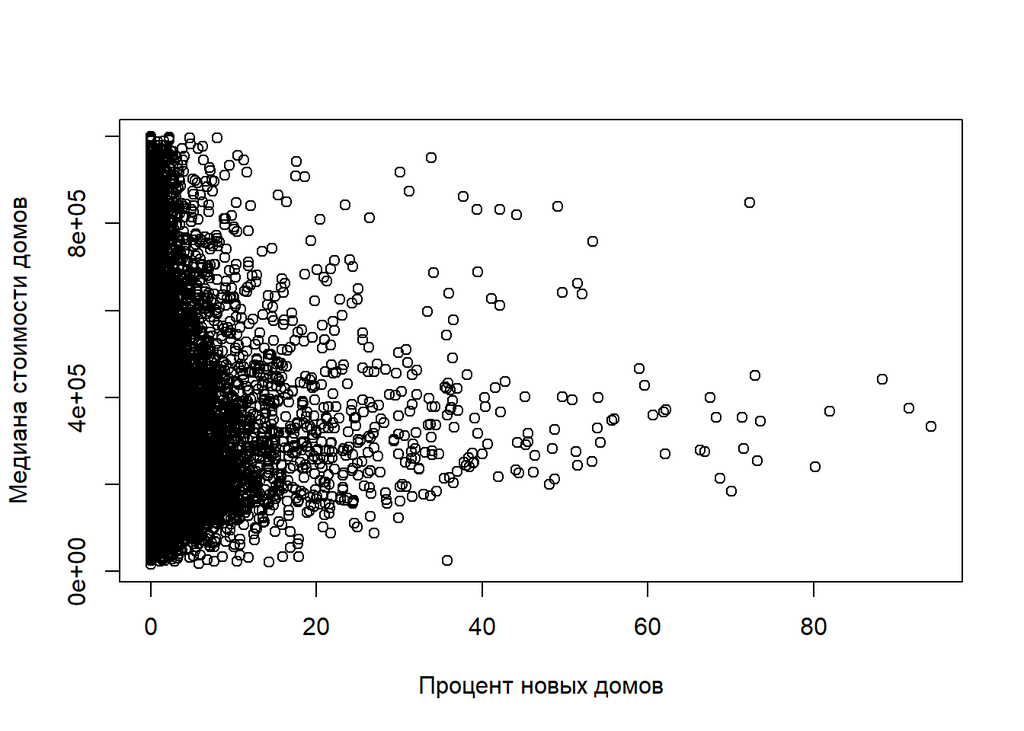

```r
plot(data$Median_house_value ~ data$Built_2005_or_later, xlab = "Процент новых домов", ylab = "Медиана стоимости домов")
```

- Постройте ещё два графика для каждого из штатов отдельно. Номер штата содержится в переменной (*STATEFP*), где Калифорния 6-й штат, а Пенсильвания 42.

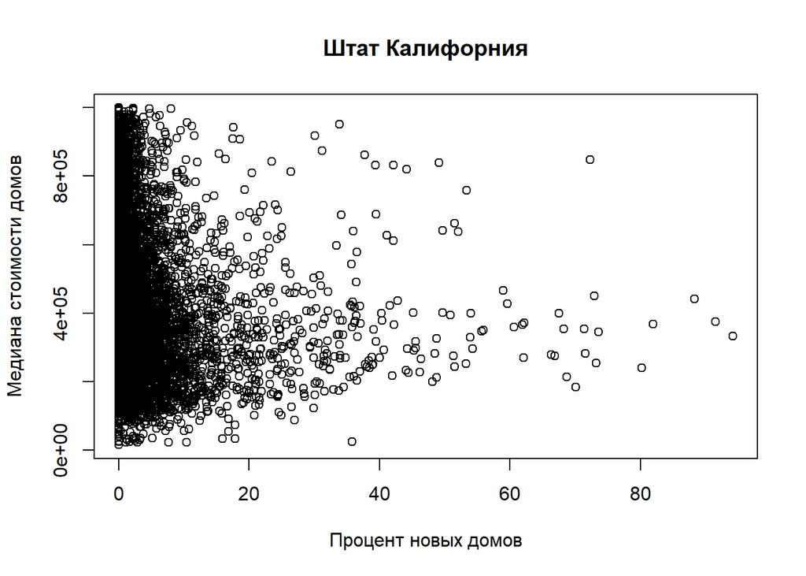

```r
California <- data$STATEFP==6
Pennsylvania <- data$STATEFP==42

plot(data$Median_house_value[California] ~ data$Built_2005_or_later[California], xlab = "Процент новых домов", ylab = "Медиана стоимости домов", main = "Штат Калифорния")
```

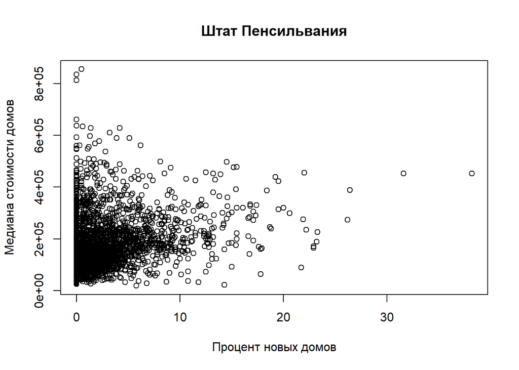

```r
plot(data$Median_house_value[Pennsylvania] ~ data$Built_2005_or_later[Pennsylvania], xlab = "Процент новых домов", ylab = "Медиана стоимости домов", main = "Штат Пенсильвания")
```

### Незанятые дома

Уровень найма (vacancy rate) — доля домов, которые не были заняты. В данных содержатся колонки, содержащие общее количество домовладений и количество не занятых домовладений. * В датафрейм *data* добавьте новую колонку *vacancy_rate*, которая должна содержать вышеописанный показатель.

```r
data$vacancy_rate <- data$Vacant_units/data$Total_units
print (ncol.2 <- ncol(data)) # изменившееся кол-во переменных
```

```
## [1] 35
```

- Найдите минимум, максимум, среднее и медиану полученных значений показателя.

Минимум: 0

Максимум: 0.965311

Среднее: 0.0888879

Медиана: 0.0676728

- Постройте диаграмму уровня найма относительно медианы стоимости домов. Что можно заметить?

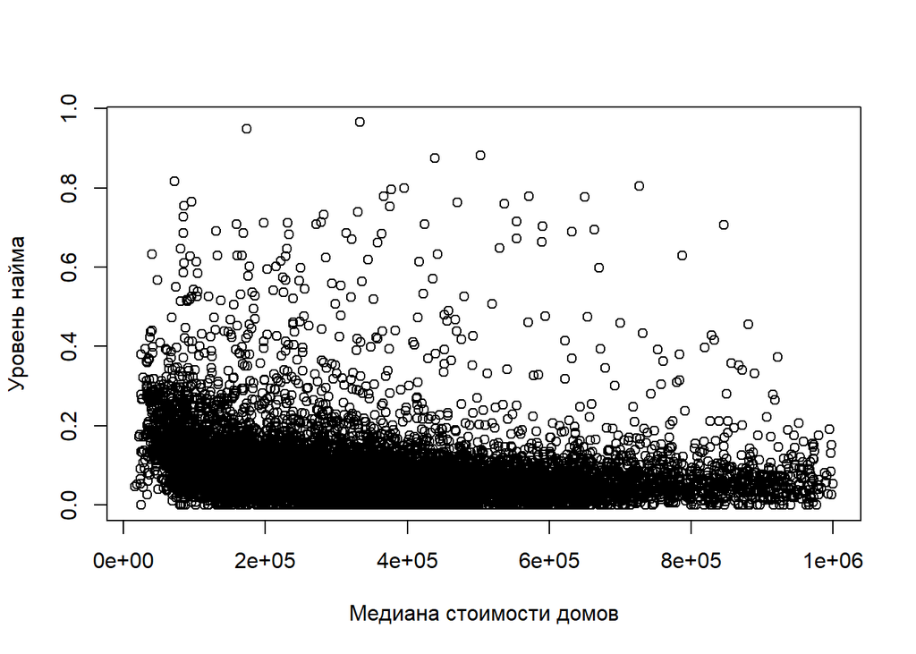

```r
plot(data$vacancy_rate ~ data$Median_house_value, xlab="Медиана стоимости домов", ylab="Уровень найма")
```

Из полученной выше диаграммы рассеяния видно, что наибольший уровень найма характерен в основном для домовладений с меньшим значением медианы стоимости.

### Корреляция

Колонка *COUNTYFP* содержит числовой код округа внутри штата. Нас интересуют Butte County (округ 7 в Калифорнии (штат 6)), Santa Clara (округ 85 в Калифорнии (штат 6)) и York County (округ 133 в Пенсильвании (штат 42)).

- Объясните, что делает приведённый в конце задания код и как именно он это делает.

```r
acc <- c()
for (tract in 1:nrow(data)) {
  if (data$STATEFP[tract] == 6) {
    if (data$COUNTYFP[tract] == 1) {
      acc <- c(acc, tract)
    }
  }
}
accmv <- c()
for (tract in acc) {
  accmv <- c(accmv, data[tract,10])
}
median(accmv)
```

```
## [1] 474050
```

В первом цикле приведенного кода просматриваются все строки датафрейма *data* и в переменную *acc* добавляются номера строк, соответствующие округу 1 в штате 6 (Калифорния). Во втором цикле в переменную *accmv* для каждого значения номера строки *tract*, сохраненного в вектор *acc*, записывается значение десятого столбца (т.е. значение медианы стоимости домовладений для каждой зоны переписи в пределах округа 1 штата Калифорния). В конце находится медиана полученного вектора *accmv*.

- Напишите другим способом в одну строку, то же самое, что делает нижеуказанный код. Способов получить тот же ответ множество, достаточно одного.

```r
median(data$Median_house_value[data$STATEFP == 6 & data$COUNTYFP == 1])
```

```
## [1] 474050
```

- Найдите средний процент построенных домовладений в округах (Butte County, Santa Clara, York County)

```r
Butte_County <- (California & data$COUNTYFP==7)
Santa_Clara <- (California & data$COUNTYFP==85)
York_County <- (Pennsylvania & data$COUNTYFP==133)

mean(data$Built_2005_or_later[Butte_County]) #средний процент построенных домовладений с 2005 г. в округе Butte County(7) штата Калифорния (6)
```

```
## [1] 4.703922
```

```r
mean(data$Built_2005_or_later[Santa_Clara]) #средний процент построенных домовладений с 2005 г. в округе Santa Clara(85) штата Калифорния (6)
```

```
## [1] 3.200319
```

```r
mean(data$Built_2005_or_later[York_County]) #средний процент построенных домовладений с 2005 г. в округе York County(133) штата Пенсильвания (42)
```

```
## [1] 4.421111
```

- Функция `cor` рассчитывает коэффициент корреляции между двумя переменными. Рассчитайте корреляцию между медианой стоимости домовладений (*Median_house_value*) и процентом построенных домов (*Built_2005_or_later*):
1. для всего набора данных
2. для Калифорнии
3. для Пенсильвании
4. для округа Butte County
5. для округа Santa Clara
6. для округа York County

```r
cor.data <- cor(data$Median_house_value, data$Built_2005_or_later) #1

cor.California <- cor(data$Median_house_value[California], data$Built_2005_or_later[California]) #2

cor.Pennsylvania <- cor(data$Median_house_value[Pennsylvania], data$Built_2005_or_later[Pennsylvania]) #3

cor.Butte_County <-cor(data$Median_house_value[Butte_County],data$Built_2005_or_later[Butte_County]) #4

cor.Santa_Clara <-cor(data$Median_house_value[Santa_Clara],data$Built_2005_or_later[Santa_Clara]) #5

cor.York_County <-cor(data$Median_house_value[York_County],data$Built_2005_or_later[York_County]) #6
```

| Условие | Значение.коэффициента.корреляции |
| --- | --- |
| Для всего набора данных | -0.0189319 |
| Для штата Калифорния | -0.1153604 |
| Для штата Пенсильвания | 0.2681654 |
| Для округа Butte County | 0.0420327 |
| Для округа Santa Clara | -0.1726203 |
| Для округа York County | 0.3860773 |

- Постройте три диаграммы медианы стоимости домовладений (*Median_house_value*) относительно медианы дохода (*Median_household_income*) для трёх округов. Допустимо указать все три на одном графике.

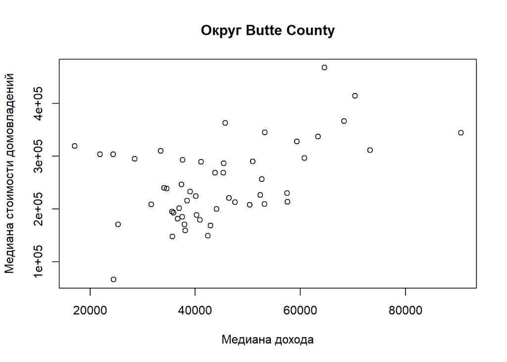

```r
plot(data$Median_house_value[Butte_County] ~ data$Median_household_income[Butte_County], xlab = "Медиана дохода", ylab = "Медиана стоимости домовладений", main="Округ Butte County")
```

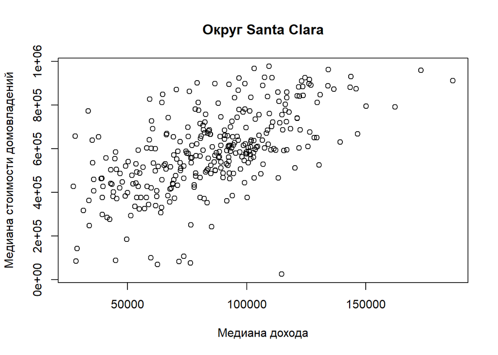

```r
plot(data$Median_house_value[Santa_Clara] ~ data$Median_household_income[Santa_Clara], xlab = "Медиана дохода", ylab = "Медиана стоимости домовладений", main="Округ Santa Clara")
```

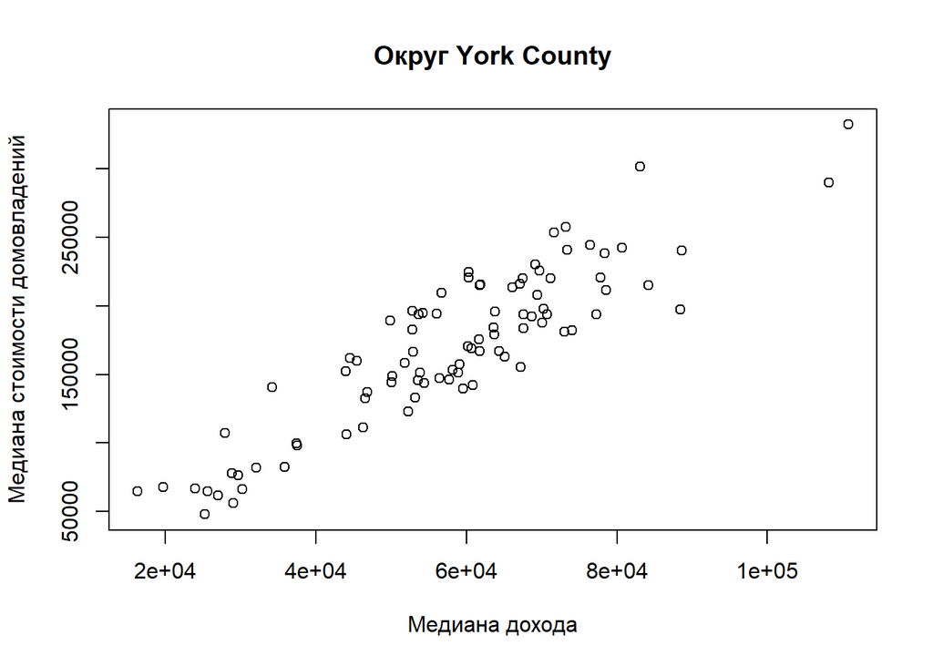

```r
plot(data$Median_house_value[York_County] ~ data$Median_household_income[York_County], xlab = "Медиана дохода", ylab = "Медиана стоимости домовладений", main="Округ York County")
```